# act_report

## UDACITY DATA ANALYST NANODEGREE PROGRAM

### PROJECT 4:

### WRANGLE AND ANALYZE DATA REPORT

### FEBURARY 4, 2022.

This Wrangle and Analyze Data Project is part of Udacity's Nanodegree Data Analyst program. This project involved wrangling (and analyzing and visualizing) data from the Twitter user @ WeRateDogs, collected from different sources connected with the tweets. WeRateDogs is a Twitter account that rates photos of people's dogs in a humorous way. These ratings almost always have a denominator of 10.

Quality performance, and tidiness problems were carried out and evaluated and then cleaned after the data had been merged. Finally, different insights and visualizations were created, and can be found below.

Insight 1: Top rated dogs

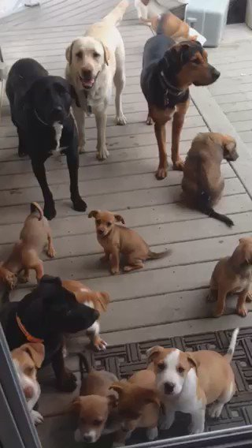

Caption: Why does this never happen at my front door?

[figure not shown]

Caption: After so many requests... here you go

Insight 2: Most retweeted dog picture

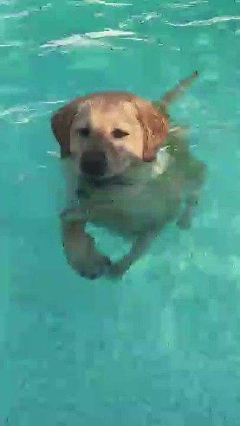

Caption: Here's a doggo realizing you can stand in a pool.

Insight 3: Tweet source type  
98% of users are using an iPhone to view tweets, 0.1% Twitter Web Client, and 0.1% are using Tweetdeck.

Insight 4: Most popular breed  
The most popular dog breed is a golden retriever that falls under the pupper dog type, with a labrador retriever coming in as the second most popular breed under the doggo type.

Insight 5: Plot on Dog types (Most rated dog type)

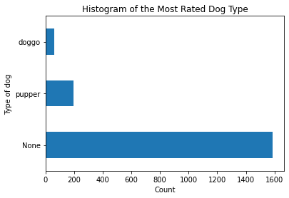

From the graph above the most famous dog type is name is unknown but PUPPER comes second followed by Doggo.

Insight 6: Correlation between retweet and Favourite count

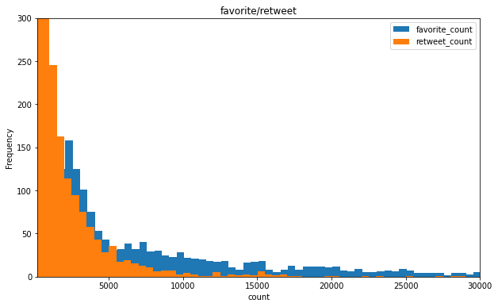

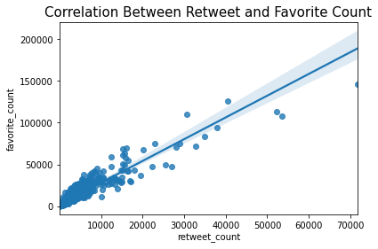

From the bar chat graph above, it clearly shown that the counts of favourites are more than the counts of retweet.

Because the most favorited and most retweeted tweets are the same, one can deduce from the secondgraph above that a higher number of retweets increases the likelihood that the tweet will also be favorited. Based on the best fit line in the graph, there is a sharp, positive connection. Every rise in the number of retweets will result in several favourite hits.